# **Predicting Laptop Prices**

- Krish Patel (118896038)
- Bodhisatta Saha (118811017)
- Aahil Sudhin (118936604)

# **Introduction**

The goal of this project is to walk you through the entire Data Science Pipeline. In order to do so, we have chosen to focus on how different features (like RAM, Storage Type, Screen, etc.) and brands of laptops affect their prices. This project is particularly relevant for consumers looking to make informed decisions when purchasing a laptop, as well as for retailers and manufacturers who aim to understand market trends and pricing strategies.

## Why is this Important?

In today's technology-driven world, laptops are an essential tool for both personal and professional use. Over time, the number of options available has increased significantly, with there being more laptop options now than ever. This often makes choosing the right laptop a daunting task. Consumers often struggle to balance their needs with their budgets, and understanding what drives the price of a laptop can significantly ease this decision-making process. Businesses and Educational Institutions need a vast array of computers to run their day-to-day operations and to give to students, so being aware of the pricing mechanisms of laptops keeps costs low when purchasing.

The hypothesis we want to test is that the brand of a laptop has a more significant influence over the price of a laptop than the actual technical specifications. This insight could reshape how consumers approach purchasing decisions and how companies market their products. If brand influence is more significant, then consumers who are impartial to brand may opt for lower-priced options with similar specs, while manufacturers might focus on brand enhancement rather than just improving technical aspects.

By analyzing laptop specifications and prices, we aim to uncover patterns that guide consumers to the best value and help manufacturers and retailers optimize their pricing strategies.

## Data Science Pipeline

Across this tutorial, we will follow the Data Science Pipeline, as shown below:

1. **Data Collection**
2. **Data Processing**
3. **Exploratory Analysis & Data Visualization**
4. **Model: Analysis, Hypothesis Testing & Machine Learning**
5. **Interpretation: Insight & Policy Decision**

# **Data Collection**:

Our goal in this section is to collect all data relevant to our project.

We will begin with our import statements, which are essential to any large scale Data Science project

```python
import os
import numpy as np
import pandas as pd
import matplotlib.pyplot as plt
import seaborn as sns
from sklearn.preprocessing import StandardScaler, OneHotEncoder
from sklearn.linear_model import LinearRegression
from sklearn.model_selection import train_test_split
from sklearn.compose import ColumnTransformer
from sklearn.pipeline import Pipeline
from sklearn.metrics import r2_score, mean_squared_error, mean_absolute_error
from sklearn.ensemble import RandomForestRegressor
```

Now we will get our data. We are using a data set from Kaggle, that we have linked below. Thankfully, this dataset has already been formatted clearly, so we don't have to make requests/scrape our data. This saves us a lot of time, and allows us to go straight to the Data Processing step of the lifecycle

All we have to do to get the data is to download the dataset from Kaggle using their API command and then use pandas to read in the data as a dataframe.

https://www.kaggle.com/datasets/muhammetvarl/laptop-price

```python
!pip install kaggle

os.environ['KAGGLE_USERNAME'] = 'krishcmsc320'
os.environ['KAGGLE_KEY'] = 'CMSC320Spr2024'

!kaggle datasets download -d muhammetvarl/laptop-price
!unzip laptop-price.zip

df = pd.read_csv('laptop_price.csv', encoding="latin-1")
df.head()
```

|  | laptop_ID | Company | Product | TypeName | Inches | ScreenResolution | Cpu | Ram | Memory | Gpu | OpSys | Weight | Price_euros |
| --- | --- | --- | --- | --- | --- | --- | --- | --- | --- | --- | --- | --- | --- |
| 0 | 1 | Apple | MacBook Pro | Ultrabook | 13.3 | IPS Panel Retina Display 2560x1600 | Intel Core i5 2.3GHz | 8GB | 128GB SSD | Intel Iris Plus Graphics 640 | macOS | 1.37kg | 1339.69 |
| 1 | 2 | Apple | Macbook Air | Ultrabook | 13.3 | 1440x900 | Intel Core i5 1.8GHz | 8GB | 128GB Flash Storage | Intel HD Graphics 6000 | macOS | 1.34kg | 898.94 |
| 2 | 3 | HP | 250 G6 | Notebook | 15.6 | Full HD 1920x1080 | Intel Core i5 7200U 2.5GHz | 8GB | 256GB SSD | Intel HD Graphics 620 | No OS | 1.86kg | 575.00 |
| 3 | 4 | Apple | MacBook Pro | Ultrabook | 15.4 | IPS Panel Retina Display 2880x1800 | Intel Core i7 2.7GHz | 16GB | 512GB SSD | AMD Radeon Pro 455 | macOS | 1.83kg | 2537.45 |
| 4 | 5 | Apple | MacBook Pro | Ultrabook | 13.3 | IPS Panel Retina Display 2560x1600 | Intel Core i5 3.1GHz | 8GB | 256GB SSD | Intel Iris Plus Graphics 650 | macOS | 1.37kg | 1803.60 |

# **Data Processing**:

In this section, we will process the data to ensure it is clean, well-structured, and ready for analysis. Data processing involves transforming raw data into a format that is suitable for analysis. This includes handling missing values, creating new columns for better clarity, and ensuring consistency in the dataset. By performing these steps, we can avoid potential errors and make the data analysis more efficient and accurate.

```python
# Check data types and basic info
print(df.info())

# Check for missing values
print(df.isnull().sum())

# Display unique values in categorical columns
print(df['Company'].unique())
print(df['TypeName'].unique())
print(df['OpSys'].unique())
```

```
<class 'pandas.core.frame.DataFrame'>
RangeIndex: 1303 entries, 0 to 1302
Data columns (total 13 columns):
 #   Column            Non-Null Count  Dtype
---  ------            --------------  -----
 0   laptop_ID         1303 non-null   int64
 1   Company           1303 non-null   object
 2   Product           1303 non-null   object
 3   TypeName          1303 non-null   object
 4   Inches            1303 non-null   float64
 5   ScreenResolution  1303 non-null   object
 6   Cpu               1303 non-null   object
 7   Ram               1303 non-null   object
 8   Memory            1303 non-null   object
 9   Gpu               1303 non-null   object
 10  OpSys             1303 non-null   object
 11  Weight            1303 non-null   object
 12  Price_euros       1303 non-null   float64
dtypes: float64(2), int64(1), object(10)
memory usage: 132.5+ KB
None
laptop_ID           0
Company             0
Product             0
TypeName            0
Inches              0
ScreenResolution    0
Cpu                 0
Ram                 0
Memory              0
Gpu                 0
OpSys               0
Weight              0
Price_euros         0
dtype: int64
['Apple' 'HP' 'Acer' 'Asus' 'Dell' 'Lenovo' 'Chuwi' 'MSI' 'Microsoft'
 'Toshiba' 'Huawei' 'Xiaomi' 'Vero' 'Razer' 'Mediacom' 'Samsung' 'Google'
 'Fujitsu' 'LG']
['Ultrabook' 'Notebook' 'Netbook' 'Gaming' '2 in 1 Convertible'
 'Workstation']
['macOS' 'No OS' 'Windows 10' 'Mac OS X' 'Linux' 'Android' 'Windows 10 S'
 'Chrome OS' 'Windows 7']
```

Now that we have our data stored, lets make sure we deal with any missing values that may cause errors or incosnsistencies in future steps

```python
# Check for missing values and drop rows with missing vals
missing_values = df.isnull().sum()
print(missing_values)
df = df.dropna()
```

```
laptop_ID           0
Company             0
Product             0
TypeName            0
Inches              0
ScreenResolution    0
Cpu                 0
Ram                 0
Memory              0
Gpu                 0
OpSys               0
Weight              0
Price_euros         0
dtype: int64
```

Now that we have dealt with the missing data values, we want to make sure that the existing data is formatted in the way that we want it to be. This involves tidying the data, splitting up existing columns into individual parts so we can classify them better, and overall breaking up the data into seperate pieces that we can individually analyze.

```python
# Convert 'Weight' to float and 'Ram' to integer while removing units
df['Weight'] = df['Weight'].str.replace('kg', '').astype(float)
df['Ram'] = df['Ram'].str.replace('GB', '').astype(int)
```

```python
# We engineer the PPI feature based on all the other screen features
df['ScreenResolution'] = df['ScreenResolution'].str.split('x')
df['Resolution_X'] = df['ScreenResolution'].apply(lambda x: x[-2].split()[-1] if len(x) > 1 else None)
df['Resolution_Y'] = df['ScreenResolution'].apply(lambda x: x[-1] if len(x) > 1 else None)
df['Resolution_X'] = df['Resolution_X'].astype(float)
df['Resolution_Y'] = df['Resolution_Y'].astype(float)
df['PPI'] = np.sqrt(df['Resolution_X']**2 + df['Resolution_Y']**2) / df['Inches'].astype(float)

# Drop the unnecessary columns
df = df.drop(columns=['laptop_ID', 'ScreenResolution', 'Resolution_X', 'Resolution_Y'])
```

```python
# We extract the brand of CPU & GPU from the CPU & GPU Columns
df['Cpu_Brand'] = df['Cpu'].apply(lambda x: x.split()[0])
df['Cpu_Model'] = df['Cpu'].apply(lambda x: ' '.join(x.split()[1:4]))

df['Gpu_Brand'] = df['Gpu'].apply(lambda x: x.split()[0])

df = df.drop(columns=['Gpu','Cpu'])
```

```python
# Convert the 'price_euros' column to 'price_USD'
exchange_rate = 1.1
df['Price_US'] = df['Price_euros'] * exchange_rate
df = df.drop(columns=['Price_euros'])
```

```python
def extract_storage_info(memory):
    # If the memory string contains a '+', it indicates combined storage, which we discard
    if '+' in memory:
        return None, None

    # Split the memory string into size (GB) and type (SSD, HDD, ...)
    size, type = memory.split()[0], memory.split()[1]

    # Convert size to GB if its in TB
    if 'TB' in size:
        size = float(size.replace('TB', '')) * 1024  # Convert TB to GB
    else:
        size = float(size.replace('GB', ''))  # Size is already in GB

    # Determine storage type
    if 'SSD' in type:
        storage_type = 'SSD'
    elif 'HDD' in type:
        storage_type = 'HDD'
    elif 'Flash' in type:
        storage_type = 'Flash'
    elif 'Hybrid' in type:
        storage_type = 'Hybrid'
    else:
        storage_type = 'Other'

    return size, storage_type

# Apply the extract_storage_info function to the 'Memory' column and create the storage size and type features
df['Storage_Size'], df['Storage_Type'] = zip(*df['Memory'].apply(extract_storage_info))
df = df.dropna(subset=['Storage_Size', 'Storage_Type'])
df = df.drop(columns=['Memory'])
```

```python
# Display the final cleaned Dataset
df
```

|  | Company | Product | TypeName | Inches | Ram | OpSys | Weight | PPI | Cpu_Brand | Cpu_Model | Gpu_Brand | Price_US | Storage_Size | Storage_Type |
| --- | --- | --- | --- | --- | --- | --- | --- | --- | --- | --- | --- | --- | --- | --- |
| 0 | Apple | MacBook Pro | Ultrabook | 13.3 | 8 | macOS | 1.37 | 226.983005 | Intel | Core i5 2.3GHz | Intel | 1473.659 | 128.0 | SSD |
| 1 | Apple | Macbook Air | Ultrabook | 13.3 | 8 | macOS | 1.34 | 127.677940 | Intel | Core i5 1.8GHz | Intel | 988.834 | 128.0 | Flash |
| 2 | HP | 250 G6 | Notebook | 15.6 | 8 | No OS | 1.86 | 141.211998 | Intel | Core i5 7200U | Intel | 632.500 | 256.0 | SSD |
| 3 | Apple | MacBook Pro | Ultrabook | 15.4 | 16 | macOS | 1.83 | 220.534624 | Intel | Core i7 2.7GHz | AMD | 2791.195 | 512.0 | SSD |
| 4 | Apple | MacBook Pro | Ultrabook | 13.3 | 8 | macOS | 1.37 | 226.983005 | Intel | Core i5 3.1GHz | Intel | 1983.960 | 256.0 | SSD |
| ... | ... | ... | ... | ... | ... | ... | ... | ... | ... | ... | ... | ... | ... | ... |
| 1298 | Lenovo | Yoga 500-14ISK | 2 in 1 Convertible | 14.0 | 4 | Windows 10 | 1.80 | 157.350512 | Intel | Core i7 6500U | Intel | 701.800 | 128.0 | SSD |
| 1299 | Lenovo | Yoga 900-13ISK | 2 in 1 Convertible | 13.3 | 16 | Windows 10 | 1.30 | 276.053530 | Intel | Core i7 6500U | Intel | 1648.900 | 512.0 | SSD |
| 1300 | Lenovo | IdeaPad 100S-14IBR | Notebook | 14.0 | 2 | Windows 10 | 1.50 | 111.935204 | Intel | Celeron Dual Core | Intel | 251.900 | 64.0 | Flash |
| 1301 | HP | 15-AC110nv (i7-6500U/6GB/1TB/Radeon | Notebook | 15.6 | 6 | Windows 10 | 2.19 | 100.454670 | Intel | Core i7 6500U | AMD | 840.400 | 1024.0 | HDD |
| 1302 | Asus | X553SA-XX031T (N3050/4GB/500GB/W10) | Notebook | 15.6 | 4 | Windows 10 | 2.20 | 100.454670 | Intel | Celeron Dual Core | Intel | 405.900 | 500.0 | HDD |

1095 rows × 14 columns

# **Exploratory Analysis & Data Visualization**:

Our goal in this section is to take a deeper dive into our data, find trends or unexpected values in the data, and analyze it using various different plots. By using data visualization techniques, we will better picture, and understand the data, which will drastically help us in our later analysis.

Let's first take a look at the overall distributions of pricing to get a general view of the data

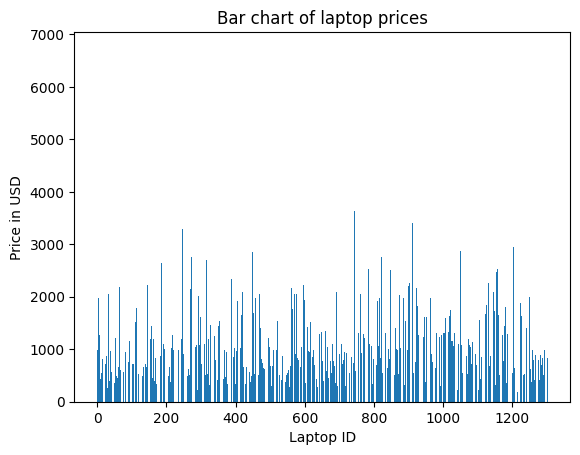

```python
import matplotlib.pyplot as plt
plt.bar(df.index, df['Price_US'])
plt.title("Bar chart of laptop prices")
plt.xlabel("Laptop ID")
plt.ylabel("Price in USD")
```

As we can see most of the prices hover around between 500 and 2500 US Dollars. let's take a closer look through a histogram

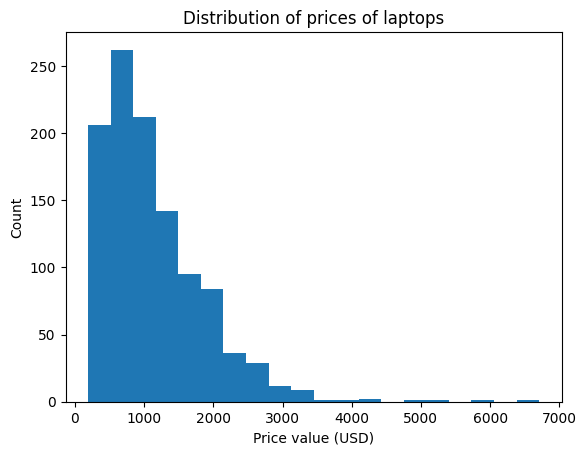

```python
plt.hist(df['Price_US'], bins = 20)
plt.title("Distribution of prices of laptops")
plt.xlabel("Price value (USD)")
plt.ylabel("Count")
```

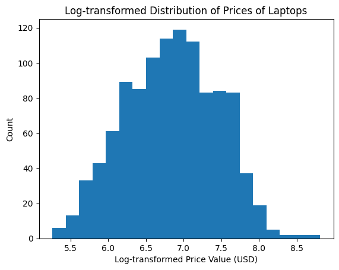

```python
#Log Transforming the data
log_prices = np.log1p(df['Price_US'])
plt.hist(log_prices, bins=20)
plt.title("Log-transformed Distribution of Prices of Laptops")
plt.xlabel("Log-transformed Price Value (USD)")
plt.ylabel("Count")
plt.show()
```

As we can see now, the distribution of prices is more normal and symmetrical and hover around an average - although there are a few outliers. Alongisde understanding what determines these outliers, we want to see what features might make an impact upon prices.

To start with, we wanted to look at the company producing the laptops. When you first go to buy a laptop, many people care about the brand they buy. Some may have a reputation for being reliable, and cheap, while others may have a reputation of being higher end and expensive. For example, there is usually a lot of hype when Apple or Microsoft drop a new computers - leading to high demand and high prices -so we wanted to take a closer look at the relative prices of laptops produced by the various manafacturers

```python
avg_price_per_brand = df.groupby('Company')['Price_US'].mean().reset_index()
avg_price_per_brand
```

|  | Company | Price_US |
| --- | --- | --- |
| 0 | Acer | 619.820629 |
| 1 | Apple | 1720.618429 |
| 2 | Asus | 924.581718 |
| 3 | Chuwi | 345.726333 |
| 4 | Dell | 1163.839266 |
| 5 | Fujitsu | 801.900000 |
| 6 | Google | 1845.433333 |
| 7 | HP | 1163.676707 |
| 8 | Huawei | 1566.400000 |
| 9 | LG | 2308.900000 |
| 10 | Lenovo | 1170.817341 |
| 11 | MSI | 1285.467333 |
| 12 | Mediacom | 324.500000 |
| 13 | Microsoft | 1773.539167 |
| 14 | Razer | 3680.757143 |
| 15 | Samsung | 1515.525000 |
| 16 | Toshiba | 1394.593750 |
| 17 | Vero | 239.167500 |
| 18 | Xiaomi | 1246.808750 |

let's plot this data for better visualization

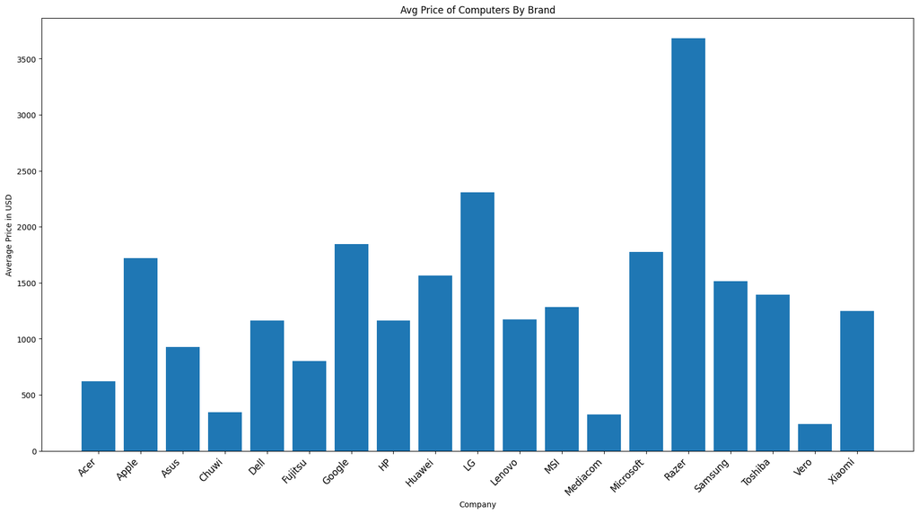

```python
plt.figure(figsize=(20, 10))  # Adjusted figure size to be less square
plt.bar(avg_price_per_brand['Company'], avg_price_per_brand['Price_US'])
plt.title("Avg Price of Computers By Brand")
plt.xticks(rotation=45, ha='right', fontsize=12)  # Rotated x-axis labels for better readability
plt.xlabel('Company')
plt.ylabel('Average Price in USD')
plt.show()
```

Now we wanted to look at the type of Laptop - whether it's a Notebook, Ultrabook, 2 in 1 Convertible, etc. It would make sense that the differences in the type, and thus the usability to some extent, drives price variances

```python
avg_price_per_type = df.groupby('TypeName')['Price_US'].mean().reset_index()
avg_price_per_type
```

|  | TypeName | Price_US |
| --- | --- | --- |
| 0 | 2 in 1 Convertible | 1405.516610 |
| 1 | Gaming | 1662.864304 |
| 2 | Netbook | 699.855200 |
| 3 | Notebook | 839.268397 |
| 4 | Ultrabook | 1708.644839 |
| 5 | Workstation | 2488.542630 |

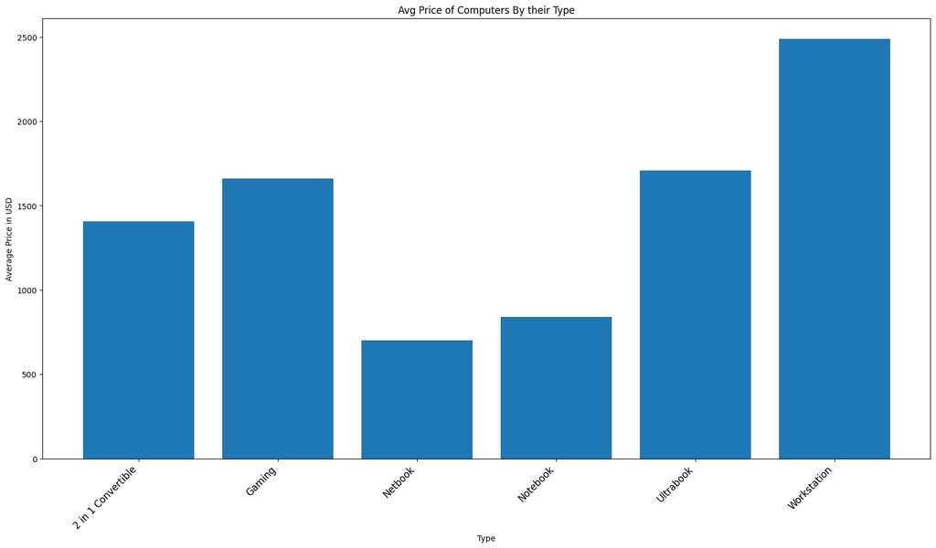

```python
plt.figure(figsize=(20, 10))  # Adjusted figure size to be less square
plt.bar(avg_price_per_type['TypeName'], avg_price_per_type['Price_US'])
plt.title("Avg Price of Computers By their Type")
plt.xticks(rotation=45, ha='right', fontsize=12)  # Rotated x-axis labels for better readability
plt.xlabel('Type')
plt.ylabel('Average Price in USD')
plt.show()
```

Now we wanted to move onto Operating System. A computer's Operating System is key to the way the computer works. For example, there are certain functionalities that Windows Operating System allows and is better for than Mac's Operating System and vice versa. An example would be for gaming - it's known that Windows Operating System provides better utilities and features for gaming than Mac Operating System and hence why there are a number of video games only available on Windows.

With this in mind, we wanted to take a deeper look into the effect of Operating System on price

```python
avg_price_per_OS = df.groupby('OpSys')['Price_US'].mean().reset_index()
avg_price_per_OS
```

|  | OpSys | Price_US |
| --- | --- | --- |
| 0 | Android | 477.400000 |
| 1 | Chrome OS | 608.943704 |
| 2 | Linux | 656.667746 |
| 3 | Mac OS X | 1389.158375 |
| 4 | No OS | 620.439742 |
| 5 | Windows 10 | 1164.584056 |
| 6 | Windows 10 S | 1415.128000 |
| 7 | Windows 7 | 1855.316467 |
| 8 | macOS | 1924.593846 |

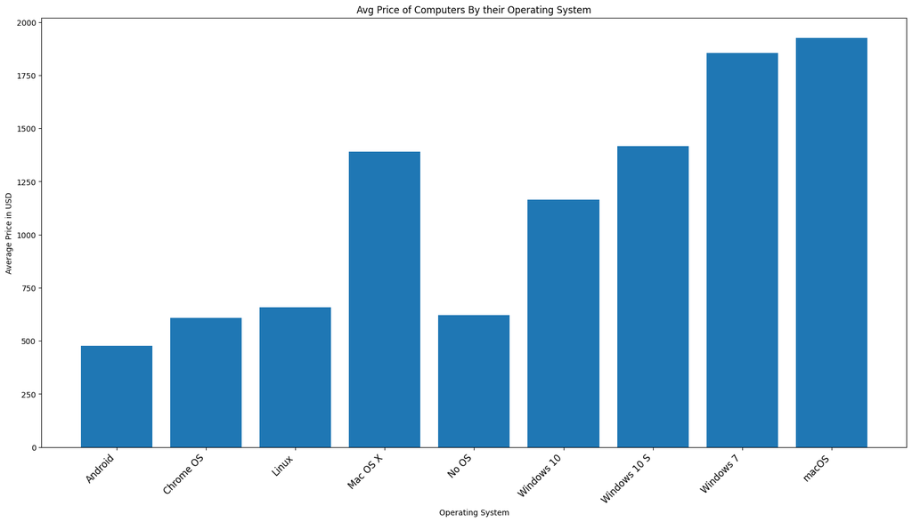

```python
plt.figure(figsize=(20, 10))  # Adjusted figure size to be less square
plt.bar(avg_price_per_OS['OpSys'], avg_price_per_OS['Price_US'])
plt.title("Avg Price of Computers By their Operating System")
plt.xticks(rotation=45, ha='right', fontsize=12)  # Rotated x-axis labels for better readability
plt.xlabel('Operating System')
plt.ylabel('Average Price in USD')
plt.show()
```

The bar plot shows that laptops with macOS and Windows 7 have the highest average prices, indicating a premium for these operating systems. In contrast, Android and Chrome OS laptops are the cheapest, reflecting their use in more budget-friendly devices. This suggests that the choice of operating system significantly influences laptop pricing.

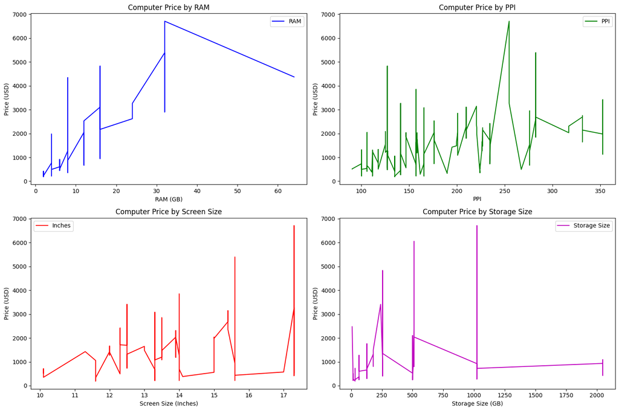

```python
# Sort the DataFrame by each feature
df_sorted_ram = df.sort_values(by='Ram')
df_sorted_ppi = df.sort_values(by='PPI')
df_sorted_inches = df.sort_values(by='Inches')
df_sorted_storage = df.sort_values(by='Storage_Size')

# Create the 2x2 subplot
fig, axs = plt.subplots(2, 2, figsize=(15, 10))

# Plot for RAM
axs[0, 0].plot(df_sorted_ram['Ram'], df_sorted_ram['Price_US'], label='RAM', color='b')
axs[0, 0].set_xlabel("RAM (GB)")
axs[0, 0].set_ylabel("Price (USD)")
axs[0, 0].set_title("Computer Price by RAM")
axs[0, 0].legend()

# Plot for PPI
axs[0, 1].plot(df_sorted_ppi['PPI'], df_sorted_ppi['Price_US'], label='PPI', color='g')
axs[0, 1].set_xlabel("PPI")
axs[0, 1].set_ylabel("Price (USD)")
axs[0, 1].set_title("Computer Price by PPI")
axs[0, 1].legend()

# Plot for Inches
axs[1, 0].plot(df_sorted_inches['Inches'], df_sorted_inches['Price_US'], label='Inches', color='r')
axs[1, 0].set_xlabel("Screen Size (Inches)")
axs[1, 0].set_ylabel("Price (USD)")
axs[1, 0].set_title("Computer Price by Screen Size")
axs[1, 0].legend()

# Plot for Storage Size
axs[1, 1].plot(df_sorted_storage['Storage_Size'], df_sorted_storage['Price_US'], label='Storage Size', color='m')
axs[1, 1].set_xlabel("Storage Size (GB)")
axs[1, 1].set_ylabel("Price (USD)")
axs[1, 1].set_title("Computer Price by Storage Size")
axs[1, 1].legend()

# Adjust layout
plt.tight_layout()
plt.show()
```

Looking at these graphs that outline the relationship between technical specifications - RAM, PPI, Screen Size, and Storage Size - the relationship may be correlated, but it's unclear as there isn't an overarching, concrete linear relationship in any of the graphs.

# **Model: Analysis, hypothesis testing & ML**:

In this section, we plan to use various modeling and analysis techniques, such as Linear Regression, Support Vector Machines, and Random Forests to predict values outside the scope of our data.

Here we choose the features that we will consider when making our model. We also split up our data into training and testing data, to ensure that our model can be tested properly, while still having enough data to be trained on.

```python
# Define the target variable and features
X = df.drop(columns=['Price_US', 'Cpu_Model', 'Product'])
y = np.log(df['Price_US'])

# Identify categorical and numerical columns
categorical_columns = ['Company', 'TypeName', 'Cpu_Brand', 'Gpu_Brand', 'OpSys', 'Storage_Type']
numerical_columns = ['Inches', 'Weight', 'Ram', 'PPI', 'Storage_Size']

# Use pd.get_dummies to one-hot encode the categorical variables
X = pd.get_dummies(X, columns=categorical_columns, drop_first=True)

# Split the data into training and testing sets
X_train, X_test, y_train, y_test = train_test_split(X, y, test_size=0.2, random_state=42)

# Standardize the numerical features
scaler = StandardScaler()
X_train[numerical_columns] = scaler.fit_transform(X_train[numerical_columns])
X_test[numerical_columns] = scaler.transform(X_test[numerical_columns])
```

## **Linear Regression**

Here is where we actually train the model, and use it to predict on the testing set. In order to evaluate our model, we calculate test statistics like Mean Absolute Error (MAE), Mean Squared Error (MSE), R^2 Score and more. We also display all of the feature weights that our model outputs.

```python
# Train the linear regression model
model = LinearRegression()
model.fit(X_train, y_train)

# Predict the prices on the test set
y_pred = model.predict(X_test)

# Calculate evaluation metrics
r2 = r2_score(y_test, y_pred)
mae = mean_absolute_error(y_test, y_pred)
mse_rf = mean_squared_error(y_test, y_pred)

print(f'R2 score: {r2}')
print(f'Mean Absolute Error (MAE): {mae}')
print(f"Mean Squared Error (MSE): {mse_rf}")
```

```
R2 score: 0.784481213376782
Mean Absolute Error (MAE): 0.23128980919762954
Mean Squared Error (MSE): 0.08549541707488531
```

The linear regression model achieved an R² score of 0.784, a Mean Absolute Error (MAE) of 0.231, and a Mean Squared Error (MSE) of 0.085, indicating that the model explains 78.4% of the variance in laptop prices with relatively low prediction errors, suggesting it effectively captures the relationship between laptop features and their prices.

Since the linear regression model fits the data well, we can look at the weights obtained by the model. First, we will print out a list of all the feature weights. Then, we can plot the weights by category to compare the weights of each brand, OS, and technical feature.

```python
# Print feature weights
feature_names = X_train.columns
coefficients = model.coef_

# Create a DataFrame to display feature names and their corresponding coefficients
feature_weights = pd.DataFrame({
    'Feature': feature_names,
    'Weight': coefficients
})

print("Feature Weights sorted by Weight:")
print(feature_weights.sort_values(by='Weight', ascending=False))
print()
```

```
Feature Weights sorted by Weight:
                 Feature    Weight
39       OpSys_Windows 7  1.043716
5          Company_Apple  0.844698
37      OpSys_Windows 10  0.755553
13            Company_LG  0.678338
33       OpSys_Chrome OS  0.674668
38    OpSys_Windows 10 S  0.636453
43      Storage_Type_SSD  0.592105
34           OpSys_Linux  0.584954
35        OpSys_Mac OS X  0.580421
17     Company_Microsoft  0.428172
20       Company_Toshiba  0.399367
42   Storage_Type_Hybrid  0.369666
36           OpSys_No OS  0.367970
```

[output cut: 31 more lines]

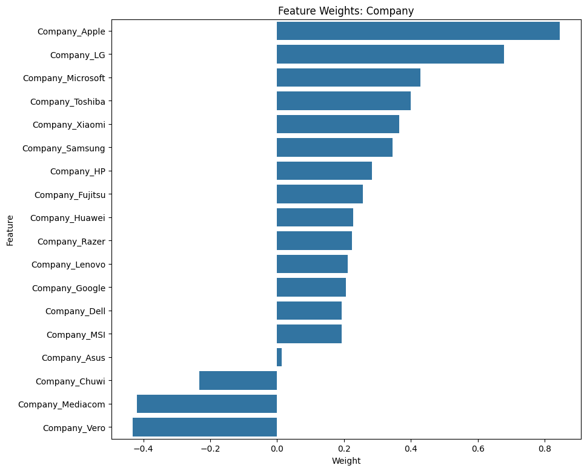

```python
# Plot the feature weights by category
def plot_feature_weights(weights_df, title):
    plt.figure(figsize=(10, len(weights_df) * 0.5))
    sns.barplot(x='Weight', y='Feature', data=weights_df.sort_values(by='Weight', ascending=False))
    plt.title(title)
    plt.xlabel('Weight')
    plt.ylabel('Feature')
    plt.show()

# Split the features by category
company_weights = feature_weights[feature_weights['Feature'].str.startswith('Company')]
plot_feature_weights(company_weights, 'Feature Weights: Company')
```

In this barplot above, we see the relative weights of each laptop manafacturer in predicting the price of the laptop. As we can see, Apple has the highest feature weight out of all companies. This means that according to the regression model, a laptop being produced by Apple will lead to the greatest increase in price compared to other companies, whether it's LG, Microsoft, Google, etc.

We also notice that some company features such as Mediacom have negative weights. This implies that a laptop produced by this company will likely be cheaper on average than laptops produced by other companies, thus decreasing the price in the regression model.

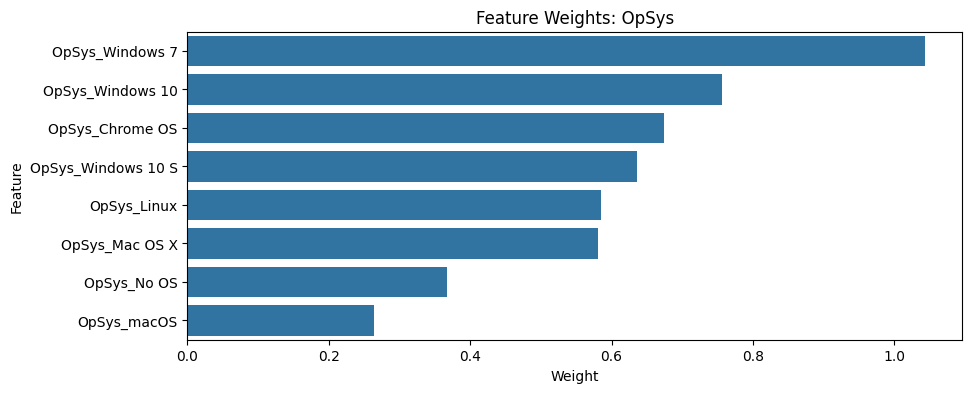

```python
os_weights = feature_weights[feature_weights['Feature'].str.startswith('OpSys')]

plot_feature_weights(os_weights, 'Feature Weights: OpSys')
```

In this barplot, we see the relative weights of Operating Systems in predicting the price of the laptop. In this case, Windows 7 has the highest feature weight, signifiying that computers with this operating system will likely have higher prices. This means that if the test case laptop we are trying to generate a price prediction for has a Windows Operating System, we should increase our price prediction at a considerably larger rate than if the test case laptop had a Chrome operating system for example.

One interesting thing to note is that macOS has the lowest feature weight, yet in the barplot above this one, we noticed that among companies, Apple had the highest feature weight. The explanation for this would be that the Mac Operating System's value is baked into Apple's value. Unlike Windows - which most computer manafacturers use for their laptops - Apple is the only laptop manafacturing company that creates laptops with MacOS, so there isn't much of an additional price increase that needs to be made upon finding out the laptop is using MacOS when we already know the company producing the laptop is Apple. Knowing this information, it also makes sense that MacOS X has a higher feature weight than a normal MacOS - because the MacOS X is more recent and a better-performing operating system than the normal MacOS so it should have some of its own price value.

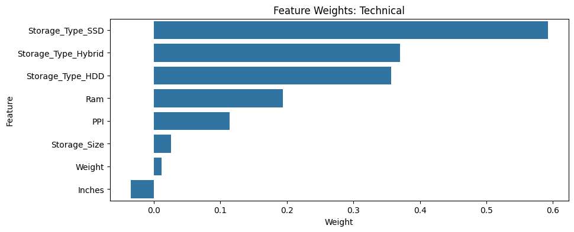

```python
numerical_weights = feature_weights[feature_weights['Feature'].isin(numerical_columns)]
storage_type_weights = feature_weights[feature_weights['Feature'].str.startswith('Storage_Type')]
technical_weights = pd.concat([numerical_weights, storage_type_weights])

plot_feature_weights(technical_weights, 'Feature Weights: Technical')
```

For our final barplot, we can see the relative feature weights of the technical elements of the laptop, such as storage type, RAM, and laptop dimensions. It's clear that Storage type as the highest direct effect on price of laptop than any of the other technical considerations. Especially in the scenario where our test case laptop has SSD Storage, we should increase the price on our price prediction by the largest amount, since SSD happens to be the fastest storage type.

## **Support Vector Machine**

Even though using the model earlier is good, we wanted to see if we could improve it. To do so, we implemented Support Vector Regression, which will give us a better prediction than our simple regression model from earlier. Below are the results of our SVR model.

```python
from sklearn.svm import SVR

# Train the SVR model
svr = SVR(kernel='rbf')
svr.fit(X_train, y_train)

# Predict the prices on the test set
y_pred = svr.predict(X_test)

# Calculate evaluation metrics
r2 = r2_score(y_test, y_pred)
mae = mean_absolute_error(y_test, y_pred)
mse_rf = mean_squared_error(y_test, y_pred)

print(f'R2 score: {r2}')
print(f'Mean Absolute Error (MAE): {mae}')
print(f"Mean Squared Error (MSE): {mse_rf}")
```

```
R2 score: 0.8524417563421274
Mean Absolute Error (MAE): 0.18689488822463843
Mean Squared Error (MSE): 0.05853574893414092
```

These results show that the SVR model performs better than our initial linear regression model. The R² score of approximately 0.852 indicates that the SVR model explains about 85.2% of the variance in laptop prices. Additionally, the MAE and MSE are lower compared to the linear regression model, suggesting that the SVR model provides more accurate predictions.

## **Random Forests**

In our quest to improve the prediction accuracy of laptop prices, we decided to try other models. To do so, we implemented random forests, which act as a series of decision trees which when aggregated, will give us a better prediction than our simple regression model from earlier.

Here we create our Random Forest model. Our forest will have 300 trees, with a max depth of 15, and will use a random 85% of the training data per sample. We train our model, and make the associated predictions. We calculate many of the same statistics as before, such a R^2 score, MAE and MSE.

```python
rf_model = RandomForestRegressor(n_estimators=300,
                              random_state=3,
                              max_samples=0.85,
                              max_features=0.75,
                              max_depth=15)

rf_model = rf_model.fit(X_train, y_train)

# Predict the prices on the test set
y_pred = rf_model.predict(X_test)

# Calculate evaluation metrics
r2 = r2_score(y_test, y_pred)
mae = mean_absolute_error(y_test, y_pred)
mse_rf = mean_squared_error(y_test, y_pred)

print(f'R2 score: {r2}')
print(f'Mean Absolute Error (MAE): {mae}')
print(f"Mean Squared Error (MSE): {mse_rf}")
```

```
R2 score: 0.8684153979238791
Mean Absolute Error (MAE): 0.1739912100104187
Mean Squared Error (MSE): 0.05219907095523163
```

The Random Forest model achieved an R² score of approximately 0.868, a Mean Absolute Error (MAE) of about 0.174, and a Mean Squared Error (MSE) of approximately 0.052. These metrics indicate that the Random Forest model outperforms our previous models, making it the best model for predicting laptop prices in our study. The Random Forest model is more accurate because it leverages the power of multiple decision trees to reduce overfitting and capture complex patterns in the data, resulting in higher predictive performance.

# **Interpretation: Insight & Policy Decision**

In this section, we analyze the insights gained from our models and discuss their implications for making informed policy decisions and strategies.

Our original hypothesis was that we believe the Brand Company and the Operating System of the laptop have a relativley stronger influence over the price of a laptop than the actual technical specifications of the laptop.

Based on our observations and analysis, we found evidence that supported this intial hypothesis.

These insights can help consumers make more informed purchasing decisions by focusing on brands that offer the best value for their money, considering that brand significantly impacts price. For brands, understanding these dynamics can guide marketing strategies and product development, enabling them to emphasize brand strengths and potentially justify higher pricing through enhanced brand reputation and customer loyalty.